# Introduction to netimpute

## Why impute both sides at once

Missing data in a network study rarely stays on one side. The respondent who skipped half the questionnaire is often the same one whose nominations are missing, so the attributes you would use to impute the ties are themselves incomplete — and the ties you would use to impute the attributes are too.

`netimpute` runs both through a single chained-equations loop. Within each iteration every incomplete attribute and every incomplete network is visited exactly once, in one interleaved, randomly ordered sequence. Whatever was updated most recently — attribute or network — feeds the next target’s predictors. Attributes are imputed from the other attributes plus node-level network measures; ties are imputed from a dyad-level model built from the attributes and the other networks.

```r
library(netimpute)
```

## The example data

Thirty employees, two networks, and four attributes. Missingness is scattered across both sides.

```r
n <- 30

make_net <- function(p) {
  m <- matrix(rbinom(n * n, 1, p), n, n)
  diag(m) <- 0
  m
}
punch <- function(m, k) {
  m[sample(which(row(m) != col(m)), k)] <- NA
  m
}

friends <- punch(make_net(0.15), 60)
advice  <- punch(make_net(0.10), 40)

staff <- data.frame(
  age    = round(rnorm(n, 40, 9)),
  female = rbinom(n, 1, 0.5),
  unit   = sample(c("sales", "eng", "hr"), n, TRUE),
  perf   = rnorm(n)
)
staff$age[sample(n, 4)]  <- NA
staff$perf[sample(n, 5)] <- NA
staff$unit[sample(n, 3)] <- NA

nets <- list(friends = friends, advice = advice)

colSums(is.na(staff))
```

```
#>    age female   unit   perf
#>      4      0      3      5
```

```r
vapply(nets, function(m) sum(is.na(m)), integer(1))
```

```
#> friends  advice
#>      60      40
```

## A first imputation

`netmice()` is the entry point. `m` is the number of imputed datasets, `maxit` the number of iterations per chain — the same meaning they have in `mice`.

```r
fit <- netmice(staff, nets, m = 5, maxit = 10, seed = 1, printFlag = FALSE)
```

```
#> netimpute: inferred attribute types -> age = continuous, female = binary, unit = multinomial, perf = continuous
#> Warning: netimpute: 11 tracked quantity/quantities have R-hat > 1.05, so the
#> chains have not converged: perf (variance) = 1.451, advice (transitivity) =
#> 1.382, friends (reciprocity) = 1.362, perf (mean) = 1.330, age (mean) = 1.315,
#> and 6 more. Increase `maxit` (currently 10) and refit.
```

```r
fit
```

```
#> Class: netmids
#> Imputations (m): 5   Iterations (maxit): 10   Method: pmm   Donors: 5   Cores: 1
#> Variables with missingness: age, unit, perf
#> Networks with missingness: friends, advice
#> Network-tie updating: sequential Gibbs (single-tie draws with change statistics)
#> Convergence (R-hat): max 1.451 (perf (variance)) - 11 above 1.05 - increase maxit
```

The message about inferred attribute types is worth reading: `netimpute` decides whether each column is continuous, binary, or multinomial, and that decision drives both how the column is imputed and what its predictor terms are called. Override it with `attr_types` if it guesses wrong.

`complete_netmice()` extracts one completed dataset — attributes and networks together.

```r
done <- complete_netmice(fit, 1)
str(done$data)
```

```
#> 'data.frame':    30 obs. of  4 variables:
#>  $ age   : num  27 45 42 49 52 49 31 42 36 46 ...
#>  $ female: int  0 1 1 0 0 0 1 1 0 1 ...
#>  $ unit  : chr  "sales" "hr" "eng" "sales" ...
#>  $ perf  : num  -0.533 0.147 0.465 0.209 -0.643 ...
```

```r
sum(is.na(done$networks$friends))
```

```
#> [1] 0
```

## Checking convergence

`plot()` shows the usual chain diagnostics on three pages: the mean and variance of the imputed values per iteration for each attribute; density, reciprocity, transitivity, isolate count and average inverse geodesic distance for each network; and, for each network that had missing ties, the mean and variance of the *imputed ties only*. You are looking for the chains to mix, not to trend.

Read the third page first. The network diagnostics on the second page are computed on the whole completed network, observed ties included, so they are diluted by the missingness fraction: with 7% of dyads missing, a swing of 0.20 in the density of the imputed cells shows up as a movement of only about 0.014 in the network’s overall density. A flat trace on page two is therefore *not* evidence of convergence when missingness is low — the imputed-tie traces are the sensitive ones, and they are what the attribute page has always shown for attributes.

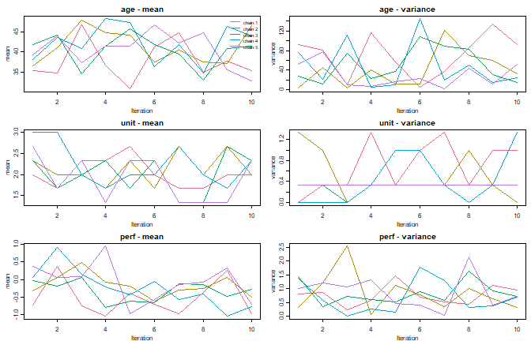

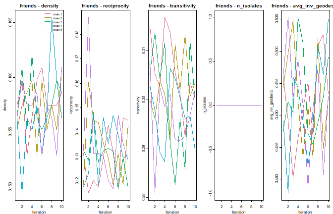

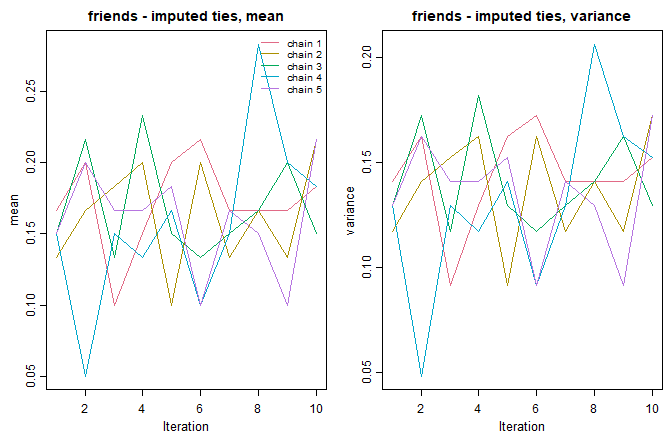

```r
plot(fit, nets = "friends", ask = FALSE)
```

If the imputed-tie traces are still drifting at the last iteration, raise `maxit`. A steadily climbing imputed-tie mean is the signature of tie inflation specifically, rather than of slow mixing in general.

The numbers behind the plots are on the fitted object: `chainMean`/`chainVar` for attributes, `netChain` for the whole-network diagnostics, and `netImpMean`/`netImpVar` for the imputed ties.

### R-hat

`netmice()` also computes rank-normalized split-R-hat for every one of those quantities, after discarding the first half of the iterations. R-hat compares the variance *between* chains to the variance *within* them: at convergence the chains are exploring the same distribution and the ratio approaches 1. Anything above 1.05 gets a warning naming the culprits.

```r
round(sort(fit$rhat, decreasing = TRUE), 3)
```

```
#>                  perf (variance)            advice (transitivity)
#>                            1.451                            1.382
#>            friends (reciprocity)                      perf (mean)
#>                            1.362                            1.330
#>                       age (mean)                  unit (variance)
#>                            1.315                            1.299
#>           friends (transitivity)             advice (reciprocity)
#>                            1.266                            1.212
#>       friends (avg_inv_geodesic)        advice (avg_inv_geodesic)
#>                            1.198                            1.115
#>                   age (variance)                      unit (mean)
#>                            1.104                            1.047
#>                 advice (density)      advice (imputed ties, mean)
#>                            1.017                            1.017
#>  advice (imputed ties, variance) friends (imputed ties, variance)
#>                            1.017                            0.948
#>                friends (density)     friends (imputed ties, mean)
#>                            0.892                            0.892
```

Two things to keep in mind when reading it. Constant traces give `NA` rather than a number — an isolate count that never moves has no within-chain variance to compare against, and that is not a failure. And R-hat is a large-sample statistic: at `maxit = 10` the burn-in leaves five iterations, which split-R-hat halves again to between two and three draws per half-chain. That is far too few to trust, in either direction, and `netmice()` says so. If you intend to take R-hat seriously, use a `maxit` in the low hundreds; the default of 20 is chosen for the trace plots, not for this.

## Using the completed data

There is no pooling helper: fit your model to each completed dataset and pool with `mice::pool()`. Anything you derive from the imputed networks — degree, centrality, a contagion term — is computed inside the loop, so its uncertainty flows into the pooled standard errors.

```r
fits <- lapply(seq_len(fit$m), function(k) {
  d <- complete_netmice(fit, k)
  d$data$friends_indeg <- colSums(d$networks$friends)
  lm(perf ~ age + friends_indeg, data = d$data)
})

summary(mice::pool(fits))
```

```
#>            term    estimate  std.error  statistic       df   p.value
#> 1   (Intercept)  0.58069171 1.14476095  0.5072602 21.08858 0.6172359
#> 2           age -0.01154801 0.02517817 -0.4586516 21.48702 0.6510899
#> 3 friends_indeg -0.08752156 0.09124524 -0.9591905 13.20365 0.3546988
```

## Predictor names: the one thing to get right

If you want to steer the imputation models yourself, you need the names of the internally generated terms — and the naming rule depends on the attribute type. **Continuous** attributes get bare `_ego` / `_alter` / `_absdiff` terms. **Binary and multinomial** attributes are dummy-coded, one term per non-reference level.

Rather than guessing, list them. `dyad_regression()` builds exactly the design `netmice()` uses at a network visit, and `fit = FALSE` stops before fitting:

```r
terms <- names(dyad_regression(nets, staff, target = "friends",
                               fit = FALSE)$data)
```

```
#> netimpute: inferred attribute types -> age = continuous, female = binary, unit = multinomial, perf = continuous
```

```r
setdiff(terms, c("i", "j", "y"))
```

```
#>  [1] "reciprocity"         "twopath"             "age_ego"
#>  [4] "age_alter"           "age_absdiff"         "female_ego_1"
#>  [7] "female_alter_1"      "female_same"         "unit_ego_hr"
#> [10] "unit_alter_hr"       "unit_ego_sales"      "unit_alter_sales"
#> [13] "unit_same"           "perf_ego"            "perf_alter"
#> [16] "perf_absdiff"        "advice_tie"          "advice_recip"
#> [19] "advice_ego_outdeg"   "advice_ego_indeg"    "advice_alter_indeg"
#> [22] "advice_alter_outdeg"
```

Note the difference between `age` (continuous) and `female` / `unit` (categorical):

```r
grep("^age",    terms, value = TRUE)
```

```
#> [1] "age_ego"     "age_alter"   "age_absdiff"
```

```r
grep("^female", terms, value = TRUE)
```

```
#> [1] "female_ego_1"   "female_alter_1" "female_same"
```

```r
grep("^unit",   terms, value = TRUE)
```

```
#> [1] "unit_ego_hr"      "unit_alter_hr"    "unit_ego_sales"   "unit_alter_sales"
#> [5] "unit_same"
```

`female` is 0/1, so it is inferred as **binary** and its term is `female_ego_1` — not `female_ego`. Had it been coded `"m"`/`"f"`, the term would be `female_ego_m` or `female_ego_f`, depending on which level sorts first and becomes the reference. This is the most common source of “why doesn’t my `models` formula work”.

The node-level names an *attribute* model can reference come from `net_measures()`, prefixed with the network name when more than one network is supplied:

```r
g <- igraph::graph_from_adjacency_matrix(
  replace(friends, is.na(friends), 0), mode = "directed", diag = FALSE)
head(names(net_measures(g, staff)), 12)
```

```
#> netimpute: inferred attribute types -> age = continuous, female = binary, unit = multinomial, perf = continuous
#>  [1] "node_id"            "outdegree"          "indegree"
#>  [4] "reciprocity_ratio"  "bonacich_power"     "betweenness"
#>  [7] "isolate"            "constraint"         "harmonic_closeness"
#> [10] "local_clustering"   "age_diff_out"       "age_diff_in"
```

Both lists are reproduced in full in the “Dyad-level term names” and “Implemented network measures” sections of `?netmice`.

## Steering the models

When `models` is left `NULL`, `netmice()` builds each imputation model automatically and prints a one-off reminder that specifying them is better. That advice is not boilerplate. An imputation model has to be at least as rich as the analysis model you intend to fit: if you will estimate an `age * female` interaction but impute without one, the imputations are drawn from a model in which that interaction is zero, and the pooled estimate is biased toward the null no matter how large `m` is. This is the congeniality requirement of Meng (1994, *Statistical Science* 9(4), 538–558); for the network case see Krause, Huisman, Steglich & Snijders (2020, *Social Networks* 62, 99–112).

`models` protects a hypothesised relationship: the terms you name always enter that target’s imputation model, whatever the automatic predictor machinery decides. Formulas are given as strings; the left-hand side names the target.

```r
fit2 <- netmice(
  staff, nets, m = 5, maxit = 10, seed = 1, printFlag = FALSE,
  models = list(
    "friends ~ female_ego_1:reciprocity",
    "perf    ~ age + friends_indegree"
  )
)
```

```
#> netimpute: inferred attribute types -> age = continuous, female = binary, unit = multinomial, perf = continuous
#> Warning: netimpute: 9 tracked quantity/quantities have R-hat > 1.05, so the
#> chains have not converged: unit (variance) = 1.273, perf (mean) = 1.270,
#> friends (transitivity) = 1.256, friends (avg_inv_geodesic) = 1.213, advice
#> (reciprocity) = 1.112, and 4 more. Increase `maxit` (currently 10) and refit.
```

The first formula is an interaction between an ego attribute and reciprocity: *do women reciprocate friendship nominations differently?* Under the default tie-wise updater (`net_update = "gibbs"`) the reciprocity factor in that interaction is re-read from the live network after **every single tie draw**, not held at its value from the start of the visit — which is what makes an endogenous interaction meaningful here.

That sweep over the missing cells is repeated `net_sweeps` times per visit (default 5), each pass in a fresh random order and conditioning on every tie drawn so far. The working model is fitted once per visit and its coefficients reused across the passes, so `net_sweeps` controls how far the network mixes toward the distribution those coefficients imply, while `maxit` controls the outer chain and is where they are re-estimated.

The endogenous terms themselves are configurable with `net_endo_terms`. Alongside `reciprocity` and the bounded `twopath` indicator, binary targets can use the geometrically weighted ERGM change statistics `gwesp`, `gwodegree` and `gwidegree` — each the movement in the corresponding network statistic if the cell went from 0 to 1, evaluated with that cell removed, so the degree terms cannot include the tie being imputed in their own predictor. They are off by default: `twopath` is bounded by 1 while `gwesp` is bounded by `exp(decay) + 2(n - 2)`, and on sparse networks a positive coefficient on it generates far too many ties. Check the imputed tie rate against the observed density before adopting them.

## Leaner models

By default every attribute and every network feature is a candidate predictor, with a PCA safeguard if that gets too wide for the number of observed cases. `netquickpred()` instead screens predictors per target by correlation, adds predictors-of-predictors recursively, and prunes collinear survivors.

```r
qp <- netquickpred(staff, nets)
```

```
#> netimpute: inferred attribute types -> age = continuous, female = binary, unit = multinomial, perf = continuous
```

```r
qp
```

```
#> Class: netquickpred (per-target predictor selection)
#> mincor: 0.1  steps: 3  collinearity: pairwise (threshold 0.9)  missingness screen: TRUE
#> Targets: age, unit, perf, friends, advice
#> - age (attribute): 3 attribute(s) + 40 network feature(s)
#>     unit [step 1], perf [step 1], female [step 2], friends_outdegree [step 1], friends_indegree [step 1], friends_reciprocity_ratio [step 1], friends_betweenness [step 1], friends_harmonic_closeness [step 1], friends_age_alter_mean_in [step 1], friends_age_alter_mean_out [step 1], friends_age_alt…
#> - unit (attribute): 3 attribute(s) + 50 network feature(s)
#>     age [step 1], female [step 1], perf [step 1], friends_outdegree [step 1], friends_indegree [step 1], friends_reciprocity_ratio [step 1], friends_betweenness [step 1], friends_constraint [step 1], friends_harmonic_closeness [step 1], friends_local_clustering [step 1], friends_age_diff_out [ste…
#> - perf (attribute): 3 attribute(s) + 44 network feature(s)
#>     age [step 1], female [step 1], unit [step 1], friends_indegree [step 1], friends_reciprocity_ratio [step 1], friends_bonacich_power [step 1], friends_betweenness [step 1], friends_local_clustering [step 1], friends_age_diff_out [step 1], friends_age_diff_in [step 1], friends_age_alter_mean [s…
#> - friends (network): 2 dyad term(s)
#>     reciprocity, twopath
#> - advice (network): 2 dyad term(s)
#>     reciprocity, twopath
```

Pass it straight to `netmice()`, or use `predictor_selection = "quickpred"` to have it computed internally:

```r
fit3 <- netmice(staff, nets, m = 5, maxit = 10, seed = 1, printFlag = FALSE,
                predictor_selection = qp)
```

```
#> netimpute: inferred attribute types -> age = continuous, female = binary, unit = multinomial, perf = continuous
#> Warning: netimpute: 6 tracked quantity/quantities have R-hat > 1.05, so the
#> chains have not converged: unit (mean) = 1.251, advice (avg_inv_geodesic) =
#> 1.207, advice (transitivity) = 1.153, advice (reciprocity) = 1.143, friends
#> (reciprocity) = 1.129, and 1 more. Increase `maxit` (currently 10) and refit.
```

### Selection and the PCA budget interact

Selection does not switch the PCA off. The `PCA` budget applies *on top* of whatever `netquickpred()` keeps, so the two have to be set with each other in mind. `PCA$ratio` is counted against observed rows — or, for a binary target, observed *events* — and at ordinary network sizes that is a much smaller number than the `mincor` screen leaves behind. When that happens the selected variables are still collapsed into components, and selection has changed *which* variables form them rather than whether components are used at all.

`netmice()` says so when it happens, once per call:

```r
invisible(netmice(staff, nets, predictor_selection = "quickpred",
                  m = 1, maxit = 2, seed = 1, printFlag = TRUE))
```

```
#> netimpute: `id` is not set, so the rows and columns of every network are assumed to be in the same order as the rows of `data`. Supply `id` to match by name instead.
#> netimpute: inferred attribute types -> age = continuous, female = binary, unit = multinomial, perf = continuous
#> netimpute: `models` is NULL, so every imputation model is built automatically from the available predictors. Supplying `models` is recommended: an imputation model should be at least as rich as the analysis model you intend to fit - one that omits its interactions or non-linearities biases the po…
#>  imputation 1 - iter 1 - order: perf -> unit -> friends -> age -> advice
#> netimpute: `predictor_selection` still leaves more predictors than the `PCA` budget for: perf (50 selected vs budget 2), unit (55 selected vs budget 2), age (46 selected vs budget 2). Those models are fitted on principal components, not on the selected variables' own coefficients - selection chan…
#>  imputation 1 - iter 2 - order: perf -> unit -> friends -> age -> advice
```

If you want named coefficients for the variables you selected, either raise `mincor` until the selection fits, or widen the budget — a *smaller* `PCA$ratio`, or an explicit `PCA$n`. Note that raising `mincor` far enough to matter can push it above the chance-correlation floor at small $n$, so check what survives before relying on it.

## Constraints on where ties can exist

`structural` marks cells that are zero *by design* — nominations that could not have been made, such as ties into another school class. They are fixed at zero, excluded from the model, and never imputed.

```r
structural <- matrix(FALSE, n, n)
structural[1:10, 11:30] <- TRUE
structural[11:30, 1:10] <- TRUE

friends_split <- friends
friends_split[structural] <- 0

fit4 <- netmice(staff, list(friends = friends_split), structural = structural,
                m = 3, maxit = 5, seed = 1, printFlag = FALSE)
```

```
#> netimpute: inferred attribute types -> age = continuous, female = binary, unit = multinomial, perf = continuous
```

```r
all(complete_netmice(fit4, 1)$networks$friends[structural] == 0)
```

```
#> [1] TRUE
```

`net_dependence` expresses logical relations *between* networks: `necessary` means a tie in the parent is required for a tie in the child, `forbidden` that two ties are mutually exclusive. Unlike `structural`, these are re-evaluated against the partner network’s current state at every visit, so the constrained set adapts as the partner is itself imputed.

```r
# advice can only run along friendship ties
friends_full <- make_net(0.25)
advice_sub   <- friends_full * matrix(rbinom(n * n, 1, 0.5), n, n)

fit5 <- netmice(
  staff,
  list(friends = punch(friends_full, 50), advice = punch(advice_sub, 50)),
  net_dependence = list(necessary = list(c("friends", "advice"))),
  m = 3, maxit = 5, seed = 1, printFlag = FALSE
)
```

```
#> netimpute: inferred attribute types -> age = continuous, female = binary, unit = multinomial, perf = continuous
```

```r
out <- complete_netmice(fit5, 1)$networks
all(out$advice[out$friends == 0 & row(out$friends) != col(out$friends)] == 0)
```

```
#> [1] TRUE
```

## Supplying networks as an edgelist

Adjacency matrices are not how most network data arrives. `networks` also accepts a single data.frame edgelist, described by `edgelist_options`.

Because an edgelist carries node *names*, they have to be resolved against something: `id` names the column of `data` holding those identifiers, and is required for edgelist input. (With matrices `id` is optional — it matches and reorders their dimnames — but supplying it is safer than trusting row order.)

```r
ids <- paste0("e", seq_len(n))
staff_id <- cbind(pid = ids, staff)

# the same `friends` network, written out as edges
present <- which(friends == 1, arr.ind = TRUE)
edges <- data.frame(from = ids[present[, 1]], to = ids[present[, 2]])
head(edges, 3)
```

```
#>   from to
#> 1   e9 e1
#> 2  e11 e1
#> 3  e12 e1
```

```r
fit_el <- netmice(staff_id, networks = edges, id = "pid",
                  m = 2, maxit = 5, seed = 1, printFlag = FALSE)
```

```
#> netimpute: inferred attribute types -> age = continuous, female = binary, unit = multinomial, perf = continuous
```

```r
dim(fit_el$networks$net1)
```

```
#> [1] 30 30
```

Note what an edgelist can and cannot say. It records which ties *exist*; every other cell is a zero by omission. So the round trip above is not lossless — `friends` had 60 cells marked `NA`, and those became zeros, because nothing in an edgelist distinguishes “no tie” from “not asked”.

That is what `missing` is for: it names the nodes whose ties are unknown, so their unlisted cells become `NA` instead of 0.

```r
fit_el2 <- netmice(staff_id, networks = edges, id = "pid",
                   edgelist_options = list(missing = ids[1:3]),
                   m = 2, maxit = 5, seed = 1, printFlag = FALSE)
```

```
#> Warning: netimpute: in network 'net1', outgoing ties listed for e1, e2, e3, yet
#> those nodes are marked missing in that same direction. An edgelist can only say
#> which ties EXIST, so netimpute treats the listed edges as observed and every
#> other cell in those rows/columns as missing - the zeros are not observed zeros.
#> If some of those zeros are genuinely observed, supply the data as
#> `edgelist_format = 'wide'` or as matrices instead.
#> netimpute: inferred attribute types -> age = continuous, female = binary, unit = multinomial, perf = continuous
```

```r
sum(is.na(fit_el2$networks$net1))
```

```
#> [1] 73
```

By default `missing` means *outgoing* ties — the actor-non-response case, where somebody did not report but others could still nominate them. Pass a list with `out` and `in` to say otherwise. netimpute warns only when the direction genuinely conflicts: a node listed as a *sender* while marked `missing$out`. Appearing as a *receiver* while marked `missing$out` is normal and stays silent.

### Several networks from one edgelist

`edgelist_split` turns one edgelist into many networks. In `"long"` format it splits on the interaction of the named columns, so `c("wave", "question")` over three waves and two questions yields six networks, named `wave_1_question_a` and so on.

```r
edges2 <- rbind(cbind(edges, wave = 1), cbind(edges[1:40, ], wave = 2))
fit_w <- netmice(staff_id, networks = edges2, id = "pid",
                 edgelist_options = list(edgelist_split = "wave"),
                 m = 2, maxit = 5, seed = 1, printFlag = FALSE)
```

```
#> netimpute: inferred attribute types -> age = continuous, female = binary, unit = multinomial, perf = continuous
```

```r
names(fit_w$networks)
```

```
#> [1] "wave_1" "wave_2"
```

In `"wide"` format each column named in `edgelist_split` is its own network, holding that tie’s value or `NA` — which is how you express partial observation that the long format cannot.

`nodelist` supplies the roster, which matters because isolates and wholly missing people never appear in an edgelist at all. It takes a column of `data`, a vector, or a named list keyed per network (or per split value, whose node sets are then intersected). A node off a network’s roster is marked **structurally absent** there: fixed at 0, never imputed. A tie whose endpoint is off the roster is an error, since it means the roster is wrong.

Any node that appears in the edgelist, `nodelist` or `missing` but not in `data` is added as a new row with all attributes missing, and `netmice()` warns, listing separately the nodes added with connections, as isolates, and entirely missing. Those are the rows whose imputations carry the most uncertainty, since nothing about them was observed.

Finally, `structural` accepts an edgelist too, listing the cells fixed at 0. It reads the same `edgelist_options`, except `missing`, which is ignored — a structural constraint is always known.

## Directed and undirected networks

```r
und <- make_net(0.25)
und[lower.tri(und)] <- t(und)[lower.tri(und)]
und[sample(which(upper.tri(und)), 40)] <- NA
und[lower.tri(und)] <- t(und)[lower.tri(und)]

fit6 <- netmice(staff, list(contact = und), m = 3, maxit = 5, seed = 1,
                printFlag = FALSE)
```

```
#> netimpute: inferred attribute types -> age = continuous, female = binary, unit = multinomial, perf = continuous
```

```r
isSymmetric(unname(complete_netmice(fit6, 1)$networks$contact))
```

```
#> [1] TRUE
```

The classification cannot be recovered after the fact: a directed network whose asymmetry happens to sit entirely in its missing cells becomes symmetric the moment those are filled. Supply the matrix with its `NA`s intact and the distinction is preserved.

## Where to go next

- `?netmice` — the full argument reference, plus complete lists of dyad-level term names and implemented network measures.
- `?netquickpred` — how predictors are screened, and the tuning arguments.
- `?dyad_regression` — the tie model on its own, usable as a standalone MR-QAP-style regression.
- `?net_measures`, `?net_predictors` — the node-level measures.

The methodology is described in Krause (2026), [arXiv:2608.05895](https://doi.org/10.48550/arXiv.2608.05895).